# HDClarity: a first look

Cohort, cUHDRS by HD category, CSF quality and Olink proteomics

2026-10-13

## About these data

**Synthetic data only**

Built only from publicly available HDClarity and Enroll-HD documentation. **No real participant data were used, seen or summarised**; no number here is a finding about HD.

- **Scope:** the HDClarity release only, meaning the PDS4 files plus the Olink Explore 3072 biosample data. The Enroll-HD visits packaged inside HDClarity are part of that release, and they hold most clinical scores.
- **Statistics:** deliberately simple. Counts, medians, Spearman correlations, and linear models adjusted for age and sex.
- **Status:** a first look to see what the data can support, not confirmatory testing.

## Four questions

1. **What is in the data?** Files, participants, visit packages and samples.
2. **Who is in it?** The cohort by HDClarity category.
3. **How does cUHDRS vary** with category, age, CAP score and stage, and which of its parts drive the differences?
4. **What do the biosamples look like?** CSF quality, then Olink: quality, batch, carriers against controls, proteins that track cUHDRS, and CSF against serum.

# The data

## How a sample links to clinical data

**Why:** every later analysis pairs a biosample with clinical scores. In HDClarity that link runs through the *visit package*, so it has to be understood first.

| Study | Visit | Visits | Role in the package |
| --- | --- | --- | --- |
| CLR | RPT Sampling | 202 | Optional repeat 4–8 weeks later (first year only) |
| CLR | Sampling | 1,416 | Lumbar puncture and blood draw within 30 days; TMS |
| CLR | Screening | 1,416 | Eligibility; clinical scales if no recent Enroll-HD visit |
| ENR | Baseline | 422 | Enroll-HD visit up to 90 days before; most clinical scales |
| ENR | Follow Up | 867 | Enroll-HD visit up to 90 days before; most clinical scales |

1,416 visit packages from 999 participants. Visits in one package share a `cycle` number.

## How many participants each analysis can use

**Why:** losses between steps set the size of every later analysis and show where data are missing by design.

|  | Participants | Packages or collections |
| --- | --- | --- |
| In the release | 999 | 1,416 |
| With a sampling visit | 999 | 1,416 |
| With a CSF quality record | 999 | 1,596 |
| With a complete cUHDRS | 913 | 1,262 |
| With more than one package | 286 | 703 |

71% of participants have a single package; consecutive packages are a median 1.0 (0.9–1.1) years apart.

# Who is in the cohort

## The cohort by HDClarity category

**Why:** the categories are defined by protocol (CAG, burden of pathology, motor diagnosis, TFC). Describing them checks they differ as intended and shows what each group brings, such as age differences that later analyses must adjust for.

|  | Control | Early pre | Late pre | Early HD | Moderate HD | Advanced HD | Incomplete penetrance |
| --- | --- | --- | --- | --- | --- | --- | --- |
| Participants | 190 | 107 | 216 | 394 | 33 | 20 | 39 |
| Female | 95 (50%) | 56 (52%) | 111 (51%) | 197 (50%) | 17 (52%) | 11 (55%) | 18 (46%) |
| Age, years | 46 (35–52) | 32 (27–39) | 42 (33–50) | 45 (38–55) | 52 (47–58) | 54 (51–64) | 62 (55–69) |
| CAG | 19 (17–22) | 42 (41–43) | 43 (42–46) | 44 (42–46) | 43 (42–45) | 44 (42–46) | 39 (39–39) |
| CAP score | – | 59 (52–66) | 86 (78–97) | 97 (84–109) | 106 (98–114) | 118 (101–145) | 83 (76–93) |
| Tertiary education | 77 (41%) | 41 (38%) | 88 (41%) | 162 (41%) | 13 (39%) | 9 (45%) | 17 (44%) |
| Australasia | 5 (3%) | <5 | 5 (2%) | 13 (3%) | <5 | <5 | <5 |
| Europe | 131 (69%) | 62 (58%) | 142 (66%) | 268 (68%) | 25 (76%) | 11 (55%) | 25 (64%) |
| Northern America | 54 (28%) | 41 (38%) | 69 (32%) | 113 (29%) | 7 (21%) | 8 (40%) | 13 (33%) |
| TMS | 0 (0–2) | 0 (0–5) | 0 (0–8) | 20 (12–27) | 55 (37–73) | 67 (51–77) | 10 (4–22) |
| TFC | 13 (13–13) | 13 (13–13) | 13 (13–13) | 11 (9–13) | 5 (5–6) | 1 (0–2) | 13 (9–13) |
| SDMT | 56 (49–63) | 50 (43–59) | 49 (40–58) | 38 (28–46) | 23 (14–34) | 3 (0–8) | 36 (27–42) |
| Stroop word reading | 102 (92–117) | 96 (86–112) | 93 (80–107) | 76 (63–90) | 47 (34–65) | 22 (8–37) | 69 (58–88) |
| cUHDRS | 17.6 (16.4–18.7) | 16.5 (15.4–18.1) | 16.4 (14.6–17.7) | 12.1 (10.2–14.1) | 4.4 (2.2–6.5) | -1.6 (-2.9–-0.3) | 13.2 (10.1–15.0) |

## HDClarity category against HD-ISS stage

**Why:** the categories mix burden, motor diagnosis and function. HD-ISS (Tabrizi et al. 2022) stages biology and function on one scale. Seeing how they overlap shows how mixed each category is.

|  | Not staged | Stage 0 | Stage 1 | Stage 2 | Stage 3 |
| --- | --- | --- | --- | --- | --- |
| Control | 190 | 0 | 0 | 0 | 0 |
| Early premanifest | 0 | 63 | 15 | 17 | 12 |
| Late premanifest | <5 | 83 | 53 | 50 | 26 |
| Early HD | 24 | 14 | 16 | 85 | 255 |
| Moderate HD | <5 | 0 | 0 | 0 | 32 |
| Advanced HD | <5 | 0 | 0 | 0 | 18 |
| Incomplete penetrance | 39 | 0 | 0 | 0 | 0 |

33% of staged pre-manifest carriers are already in HD-ISS stage 2 or 3.

# cUHDRS

## How cUHDRS is built here

**Why:** cUHDRS combines four scales into one score that is more sensitive to change than any single scale (Schobel et al. 2017). In HDClarity its parts sit on different visits, so the pairing rule has to be explicit.

$$\text{cUHDRS} = \frac{\text{TFC} - 10.4}{1.9} - \frac{\text{TMS} - 29.7}{14.9} + \frac{\text{SDMT} - 28.4}{11.3} + \frac{\text{SWR} - 66.1}{20.1} + 10$$

- **Sampling visit:** records TMS only.
- **The other three scales:** come from the package’s Enroll-HD visit, or from the HDClarity screening when no Enroll-HD visit fell in the previous 90 days.
- **Pairing rule:** within each package, use the visit with all four parts that lies closest to the sampling visit.

1,262 packages have a complete cUHDRS; 91% come from an Enroll-HD visit, a median 45 (27–63) days before sampling.

## How does cUHDRS differ across categories?

**Why:** cUHDRS is the outcome for every biomarker comparison. It should separate the categories it is meant to reflect, and the overlap between them shows how much it adds beyond the category label.

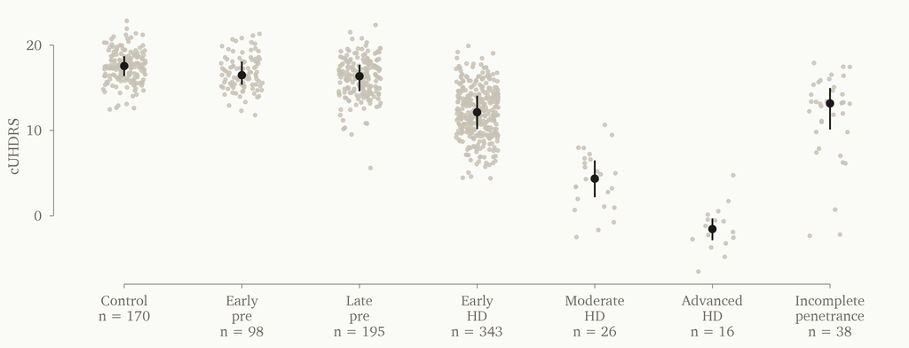

Median cUHDRS: Control 17.6 · Early pre 16.5 · Late pre 16.4 · Early HD 12.1 · Moderate HD 4.4 · Advanced HD -1.6 · Incomplete penetrance 13.2

## Is the difference just age?

**Why:** age lowers cognitive scores even without HD, and the categories differ in age. Plotting against age shows whether a category’s position is explained by how old its members are.

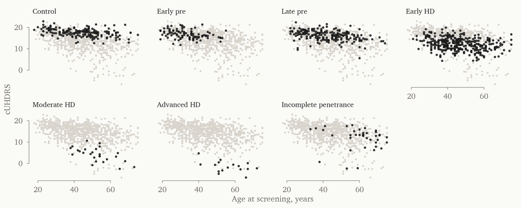

In controls, the Spearman correlation of cUHDRS with age is -0.39.

## Does cUHDRS track expected disease burden?

**Why:** the CAP score combines CAG and age into expected progression; 100 is roughly the expected age at motor diagnosis. If cUHDRS falls steadily with CAP in carriers, it measures the disease continuously, not just by category.

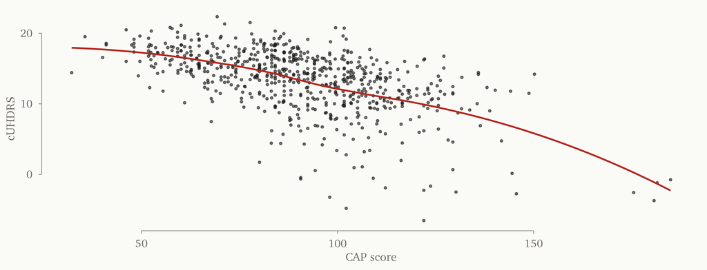

Carriers: n = 678; Spearman correlation with CAP -0.56.

## Which parts drive the differences?

**Why:** two groups can share a cUHDRS for different reasons. Splitting the difference from controls into its four parts shows whether function, motor or cognition dominates at each stage.

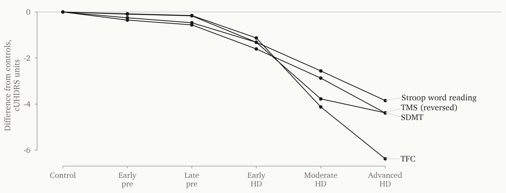

Largest drop: Early pre SDMT · Late pre SDMT · Early HD SDMT · Moderate HD TFC · Advanced HD TFC

## What do repeat packages show?

**Why:** before planning longitudinal biomarker work, check how many participants have repeated measures and over what span. The change per year is a feasibility check, not an estimate of progression.

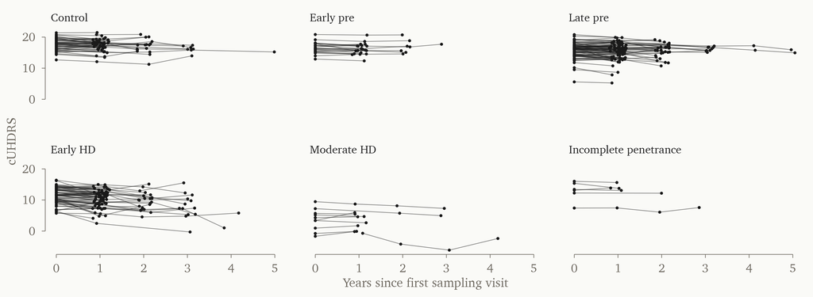

245 participants with repeats (median follow-up 1.1 years). Median change per year: Control -0.15 · Early pre -0.20 · Late pre -0.24 · Early HD -0.83 · Moderate HD -0.24 · Incomplete penetrance -0.17

# Biosamples

## Are the CSF samples clean?

**Why:** blood in CSF carries plasma proteins into the sample and can mimic or hide a CSF signal. Red-cell counts are the first quality check before any CSF biomarker analysis.

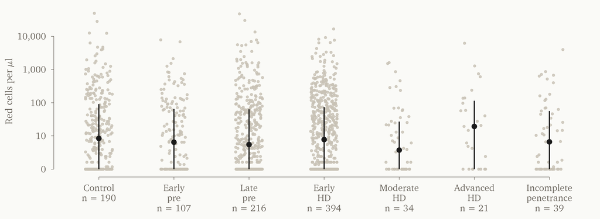

1,596 collections; median 6.7 (0.0–70.0) red cells per µl; red-cell flag on 78 (5%).

## Are the Olink data fit for analysis?

**Why:** before any biology, check three things: the samples link to clinical visits, Olink’s own QC flags are rare, and enough assays are detected above the limit of detection (LOD).

|  | Samples | Linked | Participants | QC warnings | Below LOD | Assays | Assays kept |
| --- | --- | --- | --- | --- | --- | --- | --- |
| CSF | 403 | 403 | 403 | 2.1% | 22.8% | 2,943 | 2,520 |
| Serum | 402 | 402 | 402 | 2.4% | 9.4% | 2,943 | 2,890 |

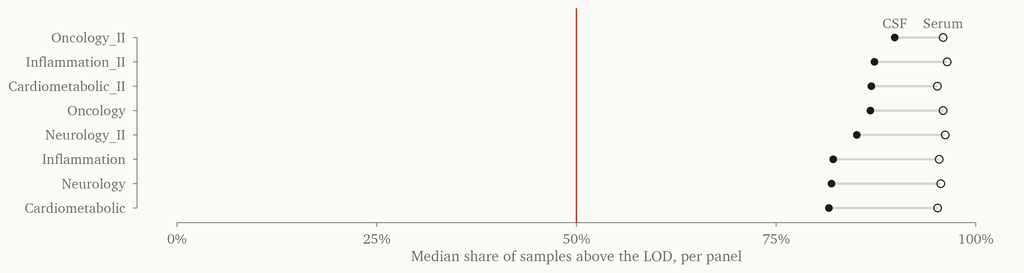

## Do plates or biology drive the protein data?

**Why:** if samples cluster by assay plate, plate effects could pass for disease effects. The main axes of variation should line up with biology (category, age), not with plates.

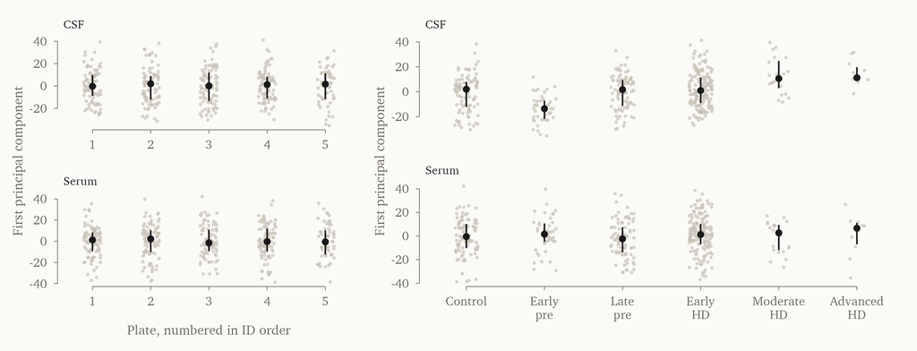

Largest R² over the first five components: CSF: plate 0, category 0.15, age 0.95 · Serum: plate 0, category 0.02, age 0.07

## Which proteins differ between carriers and controls?

**Why:** the most basic biomarker question is which proteins differ with the HD gene. Carriers and controls differ in age and sex mix, so both are adjusted for.

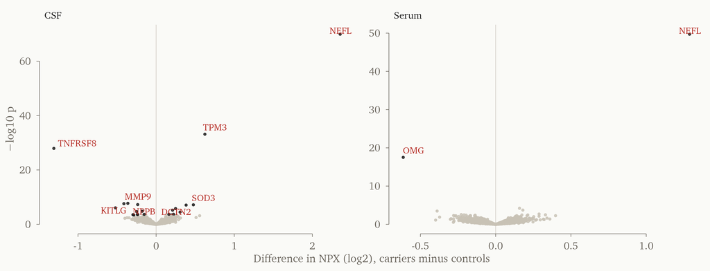

CSF: 10 higher and 12 lower of 2,520 (FDR 0.05); strongest NEFL · Serum: 1 higher and 1 lower of 2,890 (FDR 0.05); strongest NEFL

## Which proteins track cUHDRS in carriers?

**Why:** proteins that follow clinical severity *within* carriers are candidates for monitoring progression. Age drives both protein levels and cUHDRS, so the correlation is adjusted for age (and sex).

|  | Panel | Partial ρ | q (FDR) |
| --- | --- | --- | --- |
| CSF |  |  |  |
| TNFRSF8 | Neurology | 0.63 | 2.4e-28 |
| NEFL | Neurology | −0.48 | 7.7e-14 |
| TPM3 | Cardiometabolic_II | −0.48 | 1.2e-13 |
| LRP1 | Oncology | −0.36 | 5.0e-07 |
| PMVK | Neurology | −0.33 | 1.8e-05 |
| TST | Neurology | 0.30 | 1.9e-04 |
| HNF1A | Neurology_II | −0.30 | 2.6e-04 |
| DDHD2 | Neurology_II | −0.29 | 3.5e-04 |
| Serum |  |  |  |
| NEFL | Neurology | −0.53 | 4.0e-17 |
| S100P | Cardiometabolic | −0.35 | 6.6e-06 |
| CACNA1C | Neurology_II | −0.31 | 0.005 |
| OMG | Oncology | 0.27 | 0.006 |
| APOA2 | Inflammation_II | −0.24 | 0.045 |
| SERPINI1 | Inflammation_II | 0.23 | 0.068 |
| SCARA5 | Neurology | −0.23 | 0.068 |
| SCRIB | Cardiometabolic_II | 0.23 | 0.068 |

CSF: 31 of 2,520 proteins pass the FDR (273 carriers) · Serum: 5 of 2,890 proteins pass the FDR (273 carriers)

## Does serum reflect CSF?

**Why:** blood is far easier to collect than CSF. Proteins whose serum levels follow their CSF levels could be measured in blood. Proteins that don’t need CSF.

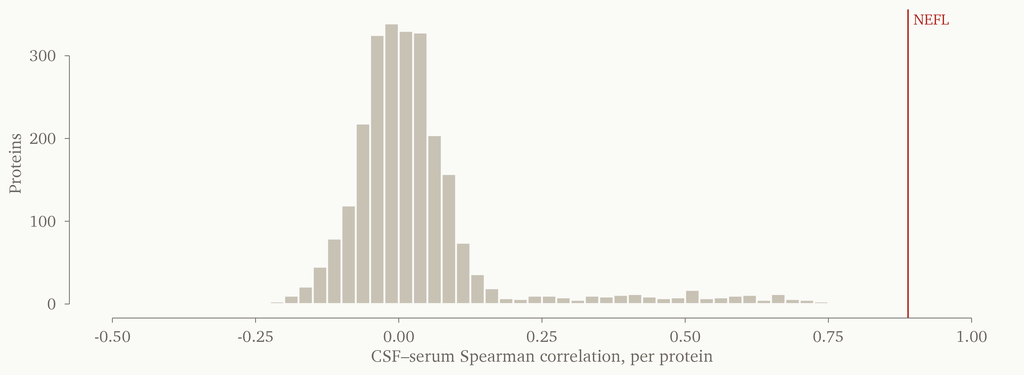

2,508 proteins; median correlation 0.01; 88 above 0.5.

## A positive check: neurofilament light

**Why:** NfL is the best-established fluid marker of neurodegeneration in HD (Byrne et al. 2017). If it does not rise across categories and fall with cUHDRS, suspect the data linkage before the biology.

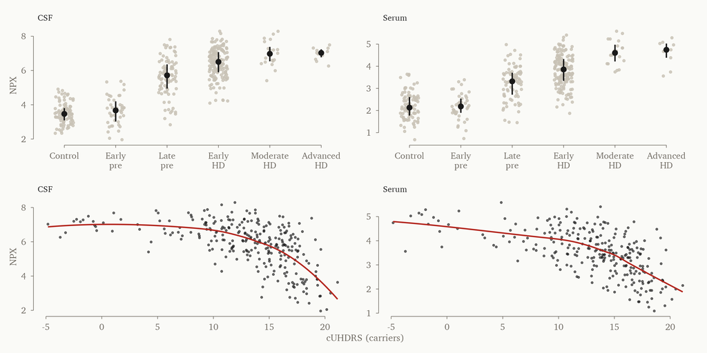

NEFL partial ρ with cUHDRS: CSF -0.48 · Serum -0.53

# Summary

## What the first look shows

- **Data:** 999 participants and 1,416 packages; 71% have one package, so the data are mostly cross-sectional.
- **cUHDRS:** complete for 1,262 packages; medians by category: Control 17.6 · Early pre 16.5 · Late pre 16.4 · Early HD 12.1 · Moderate HD 4.4 · Advanced HD -1.6 · Incomplete penetrance 13.2.
- **Tracks burden:** Spearman correlation with CAP in carriers -0.56.
- **CSF quality:** median 6.7 red cells per µl.
- **Olink, carriers against controls:** proteins passing the FDR: CSF 22, Serum 2.
- **Olink, cUHDRS in carriers:** proteins passing the FDR: CSF 31, Serum 5.

## Limitations

- **Mostly cross-sectional.** Few participants have repeat packages, over short spans.
- **A selected sample.** Exclusions for anticoagulants, high CRP, recent investigational drugs and LP risk make HDClarity healthier than Enroll-HD overall.
- **Category is carried forward.** hdcat is reviewed only at screenings 1 and 5, so it can lag behind the current stage.
- **Relative proteomics.** NPX compares samples within an assay, not absolute concentrations or levels across assays.
- **Screens, not tests.** Thousands of models, corrected for FDR, generate hypotheses to replicate.

## Possible next steps

- **Adjust for disease burden:** model proteins against cUHDRS with CAP or HD-ISS in the model, to separate disease burden from age.
- **Test–retest reliability:** use the repeat sampling visits (4–8 weeks apart) to measure the reliability of the top proteins.
- **Blood contamination:** run sensitivity analyses that exclude or adjust for heavily contaminated CSF samples.
- **Replicate the hits:** in the SomaScan data or with targeted assays.
- **Plan longitudinal analyses:** as more participants accumulate repeat packages.